# Classification using decision trees - Risk of Cancer in USA

Ambareesh Jonnavittula

29/12/2021

# Contents

- Step 1 - Problem Definition
- Step 2 - Environmental Setup
- Step 3 - Data Acquisition
- Step 4 - Data Preparation
- Step 5 - Exploratory Data Analysis
- Step 6 - Data Preprocessing
- Step 7 - Classification - Decision tree
- Step 8 - Model Evaluation

# Step 1 - Problem Definition

Over the years, there have been various carcinogenic factors which have caused Cancer among the people across all the states of USA according to NATA.

The objective of this task is to be able to prepare a classification model to utilize the predictor variables to identify and/or predict which factors potentially pose a range of risk of cancer among the people of USA.

*Note - In addition, this piece of code is reproducible, hence we could scale it to any state of the USA within the dataset*

# Step 2 - Environmental Setup

- dplyr : Data manipulations
- tidyverse : Data science tasks
- readxl : to Import the .xlsx file
- skimr : Statistical summary
- corrplot : Correlation matrix
- rpart : Classification - Decision Trees
- rattle - Decision tree visualization
- vioplot : Violin plots
- ggplot2 : Plotting graphs
- RColorBrewer : Colour palette

# Step 3 - Data Acquisition

- Import data from the file path using read_excel() function
- Rename columns for simplification

```r
## Importing / Reading the data into "df_cea_raw" data frame
df_cea_raw <- read_excel("ARM Dataset.xlsx", sheet = 1)

# Inspect the raw data
head(df_cea_raw)
```

```
## # A tibble: 6 x 20
##   State County      FIPS  Tract Population Pollutant.Name Point..includes.raily~
##   <chr> <chr>      <dbl>  <dbl>      <dbl> <chr>                           <dbl>
## 1 AK    Aleutians~  2013 2.01e9       3141 ACETALDEHYDE               0
## 2 AK    Aleutians~  2016 2.02e9       1185 ACETALDEHYDE               0.00000248
## 3 AK    Aleutians~  2016 2.02e9       4376 ACETALDEHYDE               0
## 4 AK    Anchorage~  2020 2.02e9       5736 ACETALDEHYDE               0.0000288
## 5 AK    Anchorage~  2020 2.02e9       5259 ACETALDEHYDE               0.0000607
## 6 AK    Anchorage~  2020 2.02e9       4110 ACETALDEHYDE               0.000135
## # ... with 13 more variables: Airport.Cancer.Risk..per.million. <dbl>,
## #   OR.Lightduty..includes.refueling..Cancer.Risk..per.million. <dbl>,
## #   OR.Heavyduty.Cancer.Risk..per.million. <dbl>,
## #   NR..no.airports..CMV..locomotives..Cancer.Risk..per.million. <dbl>,
## #   NP.10m.ReleaseHeight.Cancer.Risk..per.million. <dbl>,
## #   NP.Low.ReleaseHeight.Cancer.Risk..per.million. <dbl>,
## #   ResidentialWoodCombustion..RWC..Cancer.Risk..per.million. <dbl>, ...
```

```r
tail(df_cea_raw)
```

```
## # A tibble: 6 x 20
##   State County        FIPS Tract Population Pollutant.Name Point..includes.rail~
##   <chr> <chr>        <dbl> <dbl>      <dbl> <chr>                          <dbl>
## 1 WY    Sweetwater   56037     0      43806 TOLUENE                            0
## 2 WY    Teton        56039     0      21294 TOLUENE                            0
## 3 WY    Uinta        56041     0      21118 TOLUENE                            0
## 4 WY    Washakie     56043     0       8533 TOLUENE                            0
## 5 WY    Weston       56045     0       7208 TOLUENE                            0
## 6 WY    Entire state 56000     0     563624 TOLUENE                            0
## # ... with 13 more variables: Airport.Cancer.Risk..per.million. <dbl>,
## #   OR.Lightduty..includes.refueling..Cancer.Risk..per.million. <dbl>,
## #   OR.Heavyduty.Cancer.Risk..per.million. <dbl>,
## #   NR..no.airports..CMV..locomotives..Cancer.Risk..per.million. <dbl>,
## #   NP.10m.ReleaseHeight.Cancer.Risk..per.million. <dbl>,
## #   NP.Low.ReleaseHeight.Cancer.Risk..per.million. <dbl>,
## #   ResidentialWoodCombustion..RWC..Cancer.Risk..per.million. <dbl>, ...
```

```r
names(df_cea_raw)
```

```
##  [1] "State"
##  [2] "County"
##  [3] "FIPS"
##  [4] "Tract"
##  [5] "Population"
##  [6] "Pollutant.Name"
##  [7] "Point..includes.railyards..Cancer.Risk..per.million."
##  [8] "Airport.Cancer.Risk..per.million."
##  [9] "OR.Lightduty..includes.refueling..Cancer.Risk..per.million."
## [10] "OR.Heavyduty.Cancer.Risk..per.million."
## [11] "NR..no.airports..CMV..locomotives..Cancer.Risk..per.million."
## [12] "NP.10m.ReleaseHeight.Cancer.Risk..per.million."
## [13] "NP.Low.ReleaseHeight.Cancer.Risk..per.million."
## [14] "ResidentialWoodCombustion..RWC..Cancer.Risk..per.million."
## [15] "NR.CommercialMarineVessel..CMV..Cancer.Risk..per.million."
## [16] "Biogenics.Cancer.Risk..per.million."
## [17] "Fires..ag..prescribed..and.wild..Cancer.Risk..per.million."
## [18] "Secondary.Cancer.Risk..per.million."
## [19] "Background.Cancer.Risk..per.million."
## [20] "Total.Cancer.Risk..per.million."
```

```r
summary(df_cea_raw)
```

```
##     State              County               FIPS           Tract
##  Length:464075      Length:464075      Min.   : 1000   Min.   :0.000e+00
##  Class :character   Class :character   1st Qu.:13073   1st Qu.:1.208e+10
##  Mode  :character   Mode  :character   Median :28073   Median :2.616e+10
##                                        Mean   :28527   Mean   :2.720e+10
##                                        3rd Qu.:42003   3rd Qu.:4.102e+10
##                                        Max.   :78030   Max.   :7.803e+10
##    Population       Pollutant.Name
##  Min.   :       0   Length:464075
##  1st Qu.:    2910   Class :character
##  Median :    4080   Mode  :character
##  Mean   :   12121
##  3rd Qu.:    5512
##  Max.   :37253884
##  Point..includes.railyards..Cancer.Risk..per.million.
##  Min.   : 0.000000
##  1st Qu.: 0.000000
##  Median : 0.000000
##  Mean   : 0.012345
##  3rd Qu.: 0.002291
##  Max.   :14.437665
##  Airport.Cancer.Risk..per.million.
##  Min.   :0.000000
##  1st Qu.:0.000000
##  Median :0.000000
##  Mean   :0.007321
##  3rd Qu.:0.003851
##  Max.   :3.187052
##  OR.Lightduty..includes.refueling..Cancer.Risk..per.million.
##  Min.   : 0.0000
##  1st Qu.: 0.0000
##  Median : 0.0000
##  Mean   : 0.6690
##  3rd Qu.: 0.6826
##  Max.   :39.1931
##  OR.Heavyduty.Cancer.Risk..per.million.
##  Min.   :0.00000
##  1st Qu.:0.00000
##  Median :0.00000
##  Mean   :0.04181
```

[output cut: 50 more lines]

```
##  Max.   :1.85453
##  Secondary.Cancer.Risk..per.million. Background.Cancer.Risk..per.million.
##  Min.   :0.0000                      Min.   :0.000000
##  1st Qu.:0.0000                      1st Qu.:0.000000
##  Median :0.0000                      Median :0.000000
##  Mean   :0.5812                      Mean   :0.003368
##  3rd Qu.:0.0000                      3rd Qu.:0.000000
##  Max.   :6.7100                      Max.   :0.904800
##  Total.Cancer.Risk..per.million.
##  Min.   : 0.000
##  1st Qu.: 0.000
##  Median : 0.000
##  Mean   : 1.878
##  3rd Qu.: 3.486
##  Max.   :54.085
```

```r
str(df_cea_raw)
```

```
## tibble [464,075 x 20] (S3: tbl_df/tbl/data.frame)
##  $ State                                                       : chr [1:464075] "AK" "AK" "AK" "AK" ...
##  $ County                                                      : chr [1:464075] "Aleutians East Borough" "Aleutians West Census Area" "Aleutians West Census Area" "Anchorage Municipality" ...
##  $ FIPS                                                        : num [1:464075] 2013 2016 2016 2020 2020 ...
##  $ Tract                                                       : num [1:464075] 2.01e+09 2.02e+09 2.02e+09 2.02e+09 2.02e+09 ...
##  $ Population                                                  : num [1:464075] 3141 1185 4376 5736 5259 ...
##  $ Pollutant.Name                                              : chr [1:464075] "ACETALDEHYDE" "ACETALDEHYDE" "ACETALDEHYDE" "ACETALDEHYDE" ...
##  $ Point..includes.railyards..Cancer.Risk..per.million.        : num [1:464075] 0.00 2.48e-06 0.00 2.88e-05 6.07e-05 ...
##  $ Airport.Cancer.Risk..per.million.                           : num [1:464075] 0.000995 0.000119 0.005605 0.00465 0.002675 ...
##  $ OR.Lightduty..includes.refueling..Cancer.Risk..per.million. : num [1:464075] 7.19e-05 2.06e-05 1.59e-04 4.29e-02 8.50e-02 ...
##  $ OR.Heavyduty.Cancer.Risk..per.million.                      : num [1:464075] 6.81e-06 1.05e-05 1.43e-04 1.46e-02 3.79e-02 ...
##  $ NR..no.airports..CMV..locomotives..Cancer.Risk..per.million.: num [1:464075] 7.86e-05 1.41e-05 8.50e-05 4.14e-02 5.09e-02 ...
##  $ NP.10m.ReleaseHeight.Cancer.Risk..per.million.              : num [1:464075] 6.81e-05 1.60e-05 1.39e-04 2.17e-03 1.84e-03 ...
##  $ NP.Low.ReleaseHeight.Cancer.Risk..per.million.              : num [1:464075] 9.97e-07 1.29e-07 1.42e-06 6.16e-04 9.77e-04 ...
##  $ ResidentialWoodCombustion..RWC..Cancer.Risk..per.million.   : num [1:464075] 1.92e-05 1.05e-05 2.77e-07 7.50e-03 2.19e-02 ...
##  $ NR.CommercialMarineVessel..CMV..Cancer.Risk..per.million.   : num [1:464075] 7.75e-07 4.71e-06 5.11e-03 1.01e-04 1.00e-04 ...
##  $ Biogenics.Cancer.Risk..per.million.                         : num [1:464075] 0 0 0 0 0 0 0 0 0 0 ...
##  $ Fires..ag..prescribed..and.wild..Cancer.Risk..per.million.  : num [1:464075] 0 0 0 0 0 0 0 0 0 0 ...
##  $ Secondary.Cancer.Risk..per.million.                         : num [1:464075] 3.51 3.51 3.51 3.51 3.51 ...
##  $ Background.Cancer.Risk..per.million.                        : num [1:464075] 0 0 0 0 0 0 0 0 0 0 ...
##  $ Total.Cancer.Risk..per.million.                             : num [1:464075] 3.51 3.51 3.52 3.63 3.71 ...
```

```r
dim(df_cea_raw)
```

```
## [1] 464075     20
```

```r
# Renaming the columns as part of simplification
names(df_cea_raw)[names(df_cea_raw) == 'State'] <-  'state'
names(df_cea_raw)[names(df_cea_raw) == 'County'] <-  'county'
names(df_cea_raw)[names(df_cea_raw) == 'Pollutant.Name'] <-  'pollutant'
names(df_cea_raw)[names(df_cea_raw) == 'Point..includes.railyards..Cancer.Risk..per.million.'] <-  'railyards_crpm'
names(df_cea_raw)[names(df_cea_raw) == 'Airport.Cancer.Risk..per.million.'] <-  'airport_crpm'
names(df_cea_raw)[names(df_cea_raw) == 'OR.Lightduty..includes.refueling..Cancer.Risk..per.million.'] <-  'lightduty_crpm'
names(df_cea_raw)[names(df_cea_raw) == 'OR.Heavyduty.Cancer.Risk..per.million.'] <-  'heavyduty_crpm'
names(df_cea_raw)[names(df_cea_raw) == 'NR..no.airports..CMV..locomotives..Cancer.Risk..per.million.'] <-  'cmv_loco_crpm'
names(df_cea_raw)[names(df_cea_raw) == 'NP.10m.ReleaseHeight.Cancer.Risk..per.million.'] <-  'np_10m_releaseheight_crpm'
names(df_cea_raw)[names(df_cea_raw) == 'NP.Low.ReleaseHeight.Cancer.Risk..per.million.'] <-  'np_low_releaseheight_crpm'
names(df_cea_raw)[names(df_cea_raw) == 'ResidentialWoodCombustion..RWC..Cancer.Risk..per.million.'] <-  'rwc_crpm'
names(df_cea_raw)[names(df_cea_raw) == 'NR.CommercialMarineVessel..CMV..Cancer.Risk..per.million.'] <-  'cmv_crpm'
names(df_cea_raw)[names(df_cea_raw) == 'Biogenics.Cancer.Risk..per.million.'] <-  'biogenics_crpm'
names(df_cea_raw)[names(df_cea_raw) == 'Fires..ag..prescribed..and.wild..Cancer.Risk..per.million.'] <-  'fires_crpm'
names(df_cea_raw)[names(df_cea_raw) == 'Secondary.Cancer.Risk..per.million.'] <-  'secondary_crpm'
names(df_cea_raw)[names(df_cea_raw) == 'Total.Cancer.Risk..per.million.'] <-  'total_crpm'
```

# Step 4 - Data Preparation

1. Subset to consider only required columns & drop the raw dataframe
2. Inspect the subset
3. Create a function to Flatten the correlation matrix
4. Classify the level of threat into L0, L1, L2, & L3

```r
# 4.1 Subset to consider only required columns
df_cea <- select(filter(df_cea_raw)
                 ,c(state, county, pollutant,
                    railyards_crpm,
                    airport_crpm,
                    lightduty_crpm,
                    heavyduty_crpm,
                    cmv_loco_crpm,
                    np_10m_releaseheight_crpm,
                    np_low_releaseheight_crpm,
                    rwc_crpm,
                    cmv_crpm,
                    biogenics_crpm,
                    fires_crpm,
                    secondary_crpm,
                    total_crpm  ))

# 4.3 To replace missing values with 0
df_cea[is.null(df_cea)] = 0

# 4.2 Drop the raw dataframe
remove(df_cea_raw)
```

3. Inspect the subset

```r
# 4.3 Inspect the subset
# Describing the data subset
head(df_cea)
```

```
## # A tibble: 6 x 16
##   state county             pollutant  railyards_crpm airport_crpm lightduty_crpm
##   <chr> <chr>              <chr>               <dbl>        <dbl>          <dbl>
## 1 AK    Aleutians East Bo~ ACETALDEH~     0              0.000995      0.0000719
## 2 AK    Aleutians West Ce~ ACETALDEH~     0.00000248     0.000119      0.0000206
## 3 AK    Aleutians West Ce~ ACETALDEH~     0              0.00561       0.000159
## 4 AK    Anchorage Municip~ ACETALDEH~     0.0000288      0.00465       0.0429
## 5 AK    Anchorage Municip~ ACETALDEH~     0.0000607      0.00267       0.0850
## 6 AK    Anchorage Municip~ ACETALDEH~     0.000135       0.00270       0.386
## # ... with 10 more variables: heavyduty_crpm <dbl>, cmv_loco_crpm <dbl>,
## #   np_10m_releaseheight_crpm <dbl>, np_low_releaseheight_crpm <dbl>,
## #   rwc_crpm <dbl>, cmv_crpm <dbl>, biogenics_crpm <dbl>, fires_crpm <dbl>,
## #   secondary_crpm <dbl>, total_crpm <dbl>
```

```r
tail(df_cea)
```

```
## # A tibble: 6 x 16
##   state county       pollutant railyards_crpm airport_crpm lightduty_crpm
##   <chr> <chr>        <chr>              <dbl>        <dbl>          <dbl>
## 1 WY    Sweetwater   TOLUENE                0            0              0
## 2 WY    Teton        TOLUENE                0            0              0
## 3 WY    Uinta        TOLUENE                0            0              0
## 4 WY    Washakie     TOLUENE                0            0              0
## 5 WY    Weston       TOLUENE                0            0              0
## 6 WY    Entire state TOLUENE                0            0              0
## # ... with 10 more variables: heavyduty_crpm <dbl>, cmv_loco_crpm <dbl>,
## #   np_10m_releaseheight_crpm <dbl>, np_low_releaseheight_crpm <dbl>,
## #   rwc_crpm <dbl>, cmv_crpm <dbl>, biogenics_crpm <dbl>, fires_crpm <dbl>,
## #   secondary_crpm <dbl>, total_crpm <dbl>
```

```r
names(df_cea)
```

```
##  [1] "state"                     "county"
##  [3] "pollutant"                 "railyards_crpm"
##  [5] "airport_crpm"              "lightduty_crpm"
##  [7] "heavyduty_crpm"            "cmv_loco_crpm"
##  [9] "np_10m_releaseheight_crpm" "np_low_releaseheight_crpm"
## [11] "rwc_crpm"                  "cmv_crpm"
## [13] "biogenics_crpm"            "fires_crpm"
## [15] "secondary_crpm"            "total_crpm"
```

```r
str(df_cea)
```

```
## tibble [464,075 x 16] (S3: tbl_df/tbl/data.frame)
##  $ state                    : chr [1:464075] "AK" "AK" "AK" "AK" ...
##  $ county                   : chr [1:464075] "Aleutians East Borough" "Aleutians West Census Area" "Aleutians West Census Area" "Anchorage Municipality" ...
##  $ pollutant                : chr [1:464075] "ACETALDEHYDE" "ACETALDEHYDE" "ACETALDEHYDE" "ACETALDEHYDE" ...
##  $ railyards_crpm           : num [1:464075] 0.00 2.48e-06 0.00 2.88e-05 6.07e-05 ...
##  $ airport_crpm             : num [1:464075] 0.000995 0.000119 0.005605 0.00465 0.002675 ...
##  $ lightduty_crpm           : num [1:464075] 7.19e-05 2.06e-05 1.59e-04 4.29e-02 8.50e-02 ...
##  $ heavyduty_crpm           : num [1:464075] 6.81e-06 1.05e-05 1.43e-04 1.46e-02 3.79e-02 ...
##  $ cmv_loco_crpm            : num [1:464075] 7.86e-05 1.41e-05 8.50e-05 4.14e-02 5.09e-02 ...
##  $ np_10m_releaseheight_crpm: num [1:464075] 6.81e-05 1.60e-05 1.39e-04 2.17e-03 1.84e-03 ...
##  $ np_low_releaseheight_crpm: num [1:464075] 9.97e-07 1.29e-07 1.42e-06 6.16e-04 9.77e-04 ...
##  $ rwc_crpm                 : num [1:464075] 1.92e-05 1.05e-05 2.77e-07 7.50e-03 2.19e-02 ...
##  $ cmv_crpm                 : num [1:464075] 7.75e-07 4.71e-06 5.11e-03 1.01e-04 1.00e-04 ...
##  $ biogenics_crpm           : num [1:464075] 0 0 0 0 0 0 0 0 0 0 ...
##  $ fires_crpm               : num [1:464075] 0 0 0 0 0 0 0 0 0 0 ...
##  $ secondary_crpm           : num [1:464075] 3.51 3.51 3.51 3.51 3.51 ...
##  $ total_crpm               : num [1:464075] 3.51 3.51 3.52 3.63 3.71 ...
```

```r
summary(df_cea)
```

```
##     state              county           pollutant         railyards_crpm
##  Length:464075      Length:464075      Length:464075      Min.   : 0.000000
##  Class :character   Class :character   Class :character   1st Qu.: 0.000000
##  Mode  :character   Mode  :character   Mode  :character   Median : 0.000000
##                                                           Mean   : 0.012345
##                                                           3rd Qu.: 0.002291
##                                                           Max.   :14.437665
##   airport_crpm      lightduty_crpm    heavyduty_crpm    cmv_loco_crpm
##  Min.   :0.000000   Min.   : 0.0000   Min.   :0.00000   Min.   : 0.0000
##  1st Qu.:0.000000   1st Qu.: 0.0000   1st Qu.:0.00000   1st Qu.: 0.0000
##  Median :0.000000   Median : 0.0000   Median :0.00000   Median : 0.0000
##  Mean   :0.007321   Mean   : 0.6690   Mean   :0.04181   Mean   : 0.2424
##  3rd Qu.:0.003851   3rd Qu.: 0.6826   3rd Qu.:0.05851   3rd Qu.: 0.2288
##  Max.   :3.187052   Max.   :39.1931   Max.   :5.83884   Max.   :20.2247
##  np_10m_releaseheight_crpm np_low_releaseheight_crpm    rwc_crpm
##  Min.   :0.000000          Min.   :0.000000          Min.   :0.00000
##  1st Qu.:0.000000          1st Qu.:0.000000          1st Qu.:0.00000
##  Median :0.000000          Median :0.000000          Median :0.00000
##  Mean   :0.026359          Mean   :0.033904          Mean   :0.12695
##  3rd Qu.:0.002974          3rd Qu.:0.007943          3rd Qu.:0.08573
##  Max.   :9.929810          Max.   :8.068139          Max.   :9.55456
##     cmv_crpm         biogenics_crpm      fires_crpm      secondary_crpm
##  Min.   :0.0000000   Min.   :0.00000   Min.   :0.00000   Min.   :0.0000
##  1st Qu.:0.0000000   1st Qu.:0.00000   1st Qu.:0.00000   1st Qu.:0.0000
##  Median :0.0000000   Median :0.00000   Median :0.00000   Median :0.0000
##  Mean   :0.0009968   Mean   :0.07867   Mean   :0.05400   Mean   :0.5812
##  3rd Qu.:0.0000000   3rd Qu.:0.00000   3rd Qu.:0.03003   3rd Qu.:0.0000
##  Max.   :1.6072771   Max.   :1.73213   Max.   :1.85453   Max.   :6.7100
##    total_crpm
##  Min.   : 0.000
##  1st Qu.: 0.000
##  Median : 0.000
##  Mean   : 1.878
##  3rd Qu.: 3.486
##  Max.   :54.085
```

```r
# Check the number of Rows & Columns in the data subset
nrow(df_cea)
```

```
## [1] 464075
```

```r
ncol(df_cea)
```

```
## [1] 16
```

```r
dim(df_cea)
```

```
## [1] 464075     16
```

```r
skim(df_cea)
```

Data summary

| Name | df_cea |
| --- | --- |
| Number of rows | 464075 |
| Number of columns | 16 |
| _______________________ |  |
| Column type frequency: |  |
| character | 3 |
| numeric | 13 |
| ________________________ |  |
| Group variables | None |

**Variable type: character**

| skim_variable | n_missing | complete_rate | min | max | empty | n_unique | whitespace |
| --- | --- | --- | --- | --- | --- | --- | --- |
| state | 0 | 1 | 2 | 2 | 0 | 53 | 0 |
| county | 0 | 1 | 3 | 33 | 0 | 1959 | 0 |
| pollutant | 0 | 1 | 7 | 17 | 0 | 6 | 0 |

**Variable type: numeric**

| skim_variable | n_missing | complete_rate | mean | sd | p0 | p25 | p50 | p75 | p100 | hist |
| --- | --- | --- | --- | --- | --- | --- | --- | --- | --- | --- |
| railyards_crpm | 0 | 1 | 0.01 | 0.10 | 0 | 0 | 0 | 0.00 | 14.44 | ▇▁▁▁▁ |
| airport_crpm | 0 | 1 | 0.01 | 0.03 | 0 | 0 | 0 | 0.00 | 3.19 | ▇▁▁▁▁ |
| lightduty_crpm | 0 | 1 | 0.67 | 1.35 | 0 | 0 | 0 | 0.68 | 39.19 | ▇▁▁▁▁ |
| heavyduty_crpm | 0 | 1 | 0.04 | 0.08 | 0 | 0 | 0 | 0.06 | 5.84 | ▇▁▁▁▁ |
| cmv_loco_crpm | 0 | 1 | 0.24 | 0.56 | 0 | 0 | 0 | 0.23 | 20.22 | ▇▁▁▁▁ |
| np_10m_releaseheight_crpm | 0 | 1 | 0.03 | 0.12 | 0 | 0 | 0 | 0.00 | 9.93 | ▇▁▁▁▁ |
| np_low_releaseheight_crpm | 0 | 1 | 0.03 | 0.11 | 0 | 0 | 0 | 0.01 | 8.07 | ▇▁▁▁▁ |
| rwc_crpm | 0 | 1 | 0.13 | 0.32 | 0 | 0 | 0 | 0.09 | 9.55 | ▇▁▁▁▁ |
| cmv_crpm | 0 | 1 | 0.00 | 0.01 | 0 | 0 | 0 | 0.00 | 1.61 | ▇▁▁▁▁ |
| biogenics_crpm | 0 | 1 | 0.08 | 0.21 | 0 | 0 | 0 | 0.00 | 1.73 | ▇▁▁▁▁ |
| fires_crpm | 0 | 1 | 0.05 | 0.13 | 0 | 0 | 0 | 0.03 | 1.85 | ▇▁▁▁▁ |
| secondary_crpm | 0 | 1 | 0.58 | 1.38 | 0 | 0 | 0 | 0.00 | 6.71 | ▇▁▁▁▁ |
| total_crpm | 0 | 1 | 1.88 | 2.60 | 0 | 0 | 0 | 3.49 | 54.09 | ▇▁▁▁▁ |

3. Function to Flatten the correlation matrix

```r
# c is the corr. coeff. matrix
# p is the corr. p-values matrix
flat_cm <- function(c, p) {
  ut <- upper.tri(c)
  data.frame(
    row = rownames(c)[row(c)[ut]],
    column = rownames(c)[col(c)[ut]],
    cor  =(c)[ut],
    p = p[ut]
  )
}
```

4. Classify the level of threat

```r
summary(df_cea$total_crpm)
```

```
##    Min. 1st Qu.  Median    Mean 3rd Qu.    Max.
##   0.000   0.000   0.000   1.878   3.486  54.085
```

```r
df_cea$level_of_threat <- as.factor(ifelse(df_cea$total_crpm <= 0.5, 'L0',
                                ifelse(df_cea$total_crpm <= 5, 'L1',
                                       ifelse(df_cea$total_crpm <= 10, 'L2', 'L3'))))

# df_cea$level_of_threat <- cut(df_cea$total_crpm, 4, labels = c('L0', 'L1', 'L2', 'L3'))

# Check frequency
as.data.frame(table(df_cea$level_of_threat))
```

```
##   Var1   Freq
## 1   L0 246071
## 2   L1 157928
## 3   L2  55109
## 4   L3   4967
```

# Step 5 - Exploratory Data Analysis

1. Correlation plots with Pearson correlation coefficients

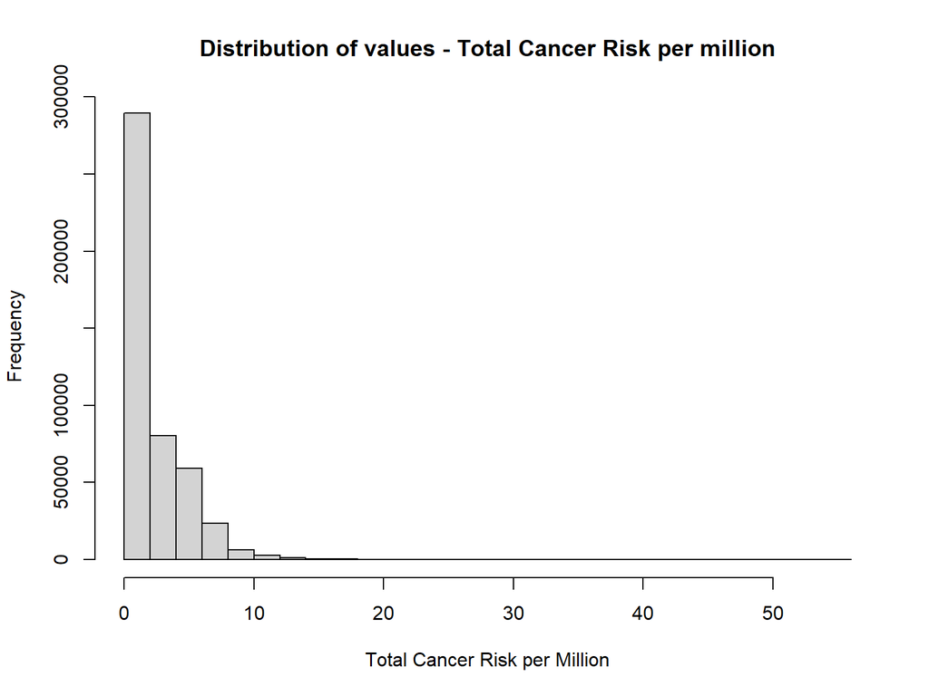

```r
# 5.1 - Histogram - Total CRPM
hist(df_cea$total_crpm, xlab="Total Cancer Risk per Million", main = "Distribution of values - Total Cancer Risk per million")
```

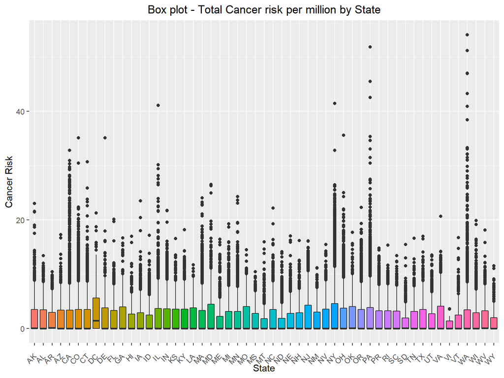

```r
# 5.2 - Box plot - Total Cancer risk by State
ggplot(df_cea, aes(x=state, y=total_crpm, fill=state)) +
  geom_boxplot()+
  labs(title="Box plot - Total Cancer risk per million by State",x="State", y = "Cancer Risk")+
  theme(legend.position = "none") +
  theme(axis.text.x = element_text(angle = 45, vjust = 0.5, hjust=1))+
  theme(plot.title = element_text(hjust = 0.5))
```

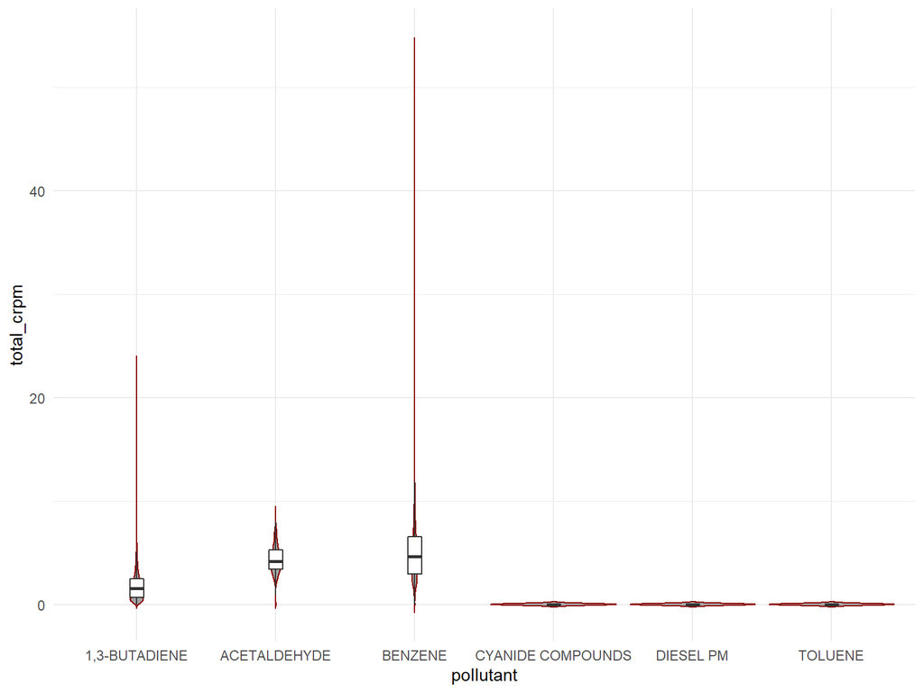

```r
# 5.3 - Violin Plot - Total CRPM by Pollutant
ggplot(df_cea, aes(x=pollutant, y=total_crpm)) +
  geom_violin(trim=FALSE, fill='#A4A4A4', color="darkred")+
  geom_boxplot(width=0.1, outlier.shape = NA) +  theme_minimal()
```

```r
# 5.4 Correlation Matrix for continuous variables
df_cea_cv <- df_cea[, c(4:16)]
df_cea_cor <- cor(df_cea_cv)
round(df_cea_cor,2)
```

```
##                           railyards_crpm airport_crpm lightduty_crpm
## railyards_crpm                      1.00         0.05           0.17
## airport_crpm                        0.05         1.00           0.24
## lightduty_crpm                      0.17         0.24           1.00
## heavyduty_crpm                      0.11         0.27           0.73
## cmv_loco_crpm                       0.12         0.26           0.84
## np_10m_releaseheight_crpm           0.15         0.01           0.33
## np_low_releaseheight_crpm           0.12         0.11           0.71
## rwc_crpm                            0.09         0.13           0.62
## cmv_crpm                            0.05         0.06           0.20
## biogenics_crpm                     -0.02        -0.04          -0.15
## fires_crpm                          0.20         0.04           0.43
## secondary_crpm                     -0.02        -0.03          -0.15
## total_crpm                          0.18         0.21           0.78
##                           heavyduty_crpm cmv_loco_crpm
## railyards_crpm                      0.11          0.12
## airport_crpm                        0.27          0.26
## lightduty_crpm                      0.73          0.84
## heavyduty_crpm                      1.00          0.70
## cmv_loco_crpm                       0.70          1.00
## np_10m_releaseheight_crpm           0.22          0.24
## np_low_releaseheight_crpm           0.52          0.69
## rwc_crpm                            0.46          0.52
## cmv_crpm                            0.22          0.26
## biogenics_crpm                      0.02         -0.13
## fires_crpm                          0.27          0.32
## secondary_crpm                      0.07         -0.14
## total_crpm                          0.72          0.72
##                           np_10m_releaseheight_crpm np_low_releaseheight_crpm
## railyards_crpm                                 0.15                      0.12
## airport_crpm                                   0.01                      0.11
## lightduty_crpm                                 0.33                      0.71
## heavyduty_crpm                                 0.22                      0.52
## cmv_loco_crpm                                  0.24                      0.69
## np_10m_releaseheight_crpm                      1.00                      0.29
## np_low_releaseheight_crpm                      0.29                      1.00
## rwc_crpm                                       0.29                      0.37
## cmv_crpm                                       0.08                      0.24
## biogenics_crpm                                -0.07                     -0.09
## fires_crpm                                     0.42                      0.39
```

[output cut: 15 more lines]

```
## total_crpm                    0.55     0.23           0.44       0.34
##                           secondary_crpm total_crpm
## railyards_crpm                     -0.02       0.18
## airport_crpm                       -0.03       0.21
## lightduty_crpm                     -0.15       0.78
## heavyduty_crpm                      0.07       0.72
## cmv_loco_crpm                      -0.14       0.72
## np_10m_releaseheight_crpm          -0.08       0.30
## np_low_releaseheight_crpm          -0.09       0.61
## rwc_crpm                           -0.11       0.55
## cmv_crpm                            0.05       0.23
## biogenics_crpm                      0.92       0.44
## fires_crpm                         -0.14       0.34
## secondary_crpm                      1.00       0.47
## total_crpm                          0.47       1.00
```

```r
# 5.5 Apply Flatten function here
rs<-rcorr(as.matrix(df_cea[, c(4:16)]))
flat_cm(rs$r, rs$P)
```

```
##                          row                    column          cor
## 1             railyards_crpm              airport_crpm  0.050096306
## 2             railyards_crpm            lightduty_crpm  0.172332257
## 3               airport_crpm            lightduty_crpm  0.237628510
## 4             railyards_crpm            heavyduty_crpm  0.108300827
## 5               airport_crpm            heavyduty_crpm  0.266389871
## 6             lightduty_crpm            heavyduty_crpm  0.734609525
## 7             railyards_crpm             cmv_loco_crpm  0.121881816
## 8               airport_crpm             cmv_loco_crpm  0.259299573
## 9             lightduty_crpm             cmv_loco_crpm  0.836562500
## 10            heavyduty_crpm             cmv_loco_crpm  0.701181851
## 11            railyards_crpm np_10m_releaseheight_crpm  0.149935390
## 12              airport_crpm np_10m_releaseheight_crpm  0.008782237
## 13            lightduty_crpm np_10m_releaseheight_crpm  0.325073521
## 14            heavyduty_crpm np_10m_releaseheight_crpm  0.222543753
```

[output cut: 143 more lines]

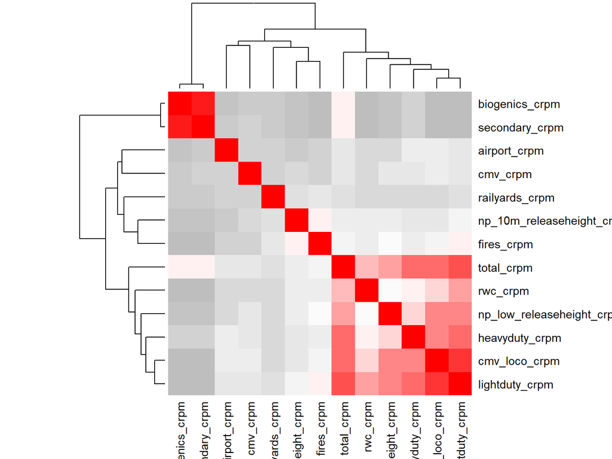

```r
# 5.6 - Correlation Matrix Analysis using Heatmap
col <- colorRampPalette(c("grey", "white", "red"))(20)
heatmap(x = df_cea_cor, col = col, symm = TRUE)
```

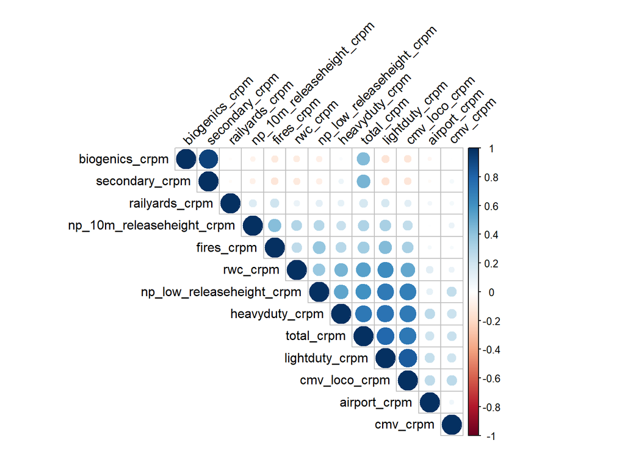

```r
# 5.7 - Correlogram
corrplot(df_cea_cor, type = "upper", order = "hclust",
         tl.col = "black", tl.srt = 45)
```

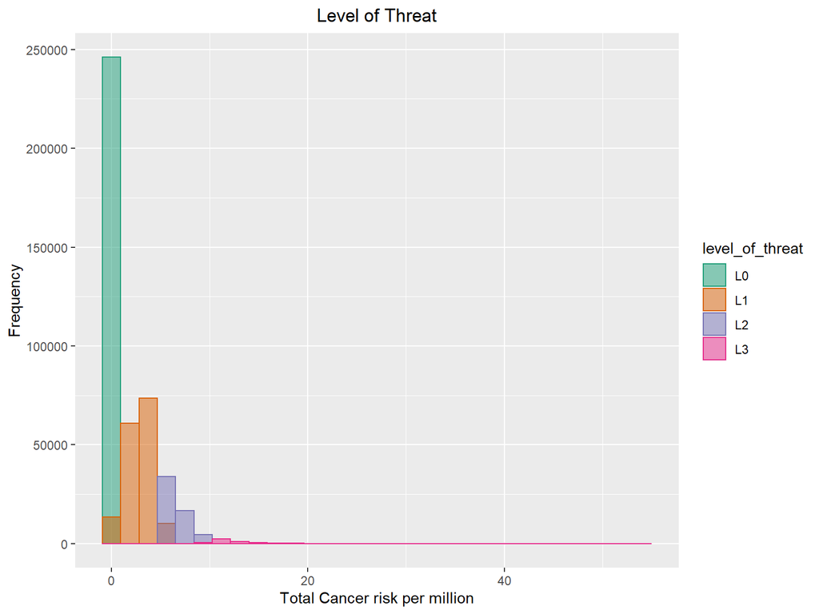

```r
# 5.8 - Level of Threat
ggplot(df_cea, aes(x=total_crpm, fill=level_of_threat, color=level_of_threat)) +
  geom_histogram( alpha=0.5, position="identity")+
  scale_color_brewer(palette="Dark2")+
  scale_fill_brewer(palette="Dark2")+
  labs(title="Level of Threat",x="Total Cancer risk per million", y = "Frequency")+
  theme(plot.title = element_text(hjust = 0.5))
```

# Step 6 - Data Preprocessing

```r
# Subset to only predictor and response variables.
df_cea_model <- df_cea[, 4:17]
names(df_cea_model)
```

```
##  [1] "railyards_crpm"            "airport_crpm"
##  [3] "lightduty_crpm"            "heavyduty_crpm"
##  [5] "cmv_loco_crpm"             "np_10m_releaseheight_crpm"
##  [7] "np_low_releaseheight_crpm" "rwc_crpm"
##  [9] "cmv_crpm"                  "biogenics_crpm"
## [11] "fires_crpm"                "secondary_crpm"
## [13] "total_crpm"                "level_of_threat"
```

```r
# Write the .csv file for SAS task
write.csv(df_cea_model,"D:/University/ASDM/Developments/Task 1 - Classification/Cancer_Risk_USA_SAS.csv", row.names = TRUE)

# Random number generator
set.seed(28)

# Use Sampling function to split the training vs. test datasets.
cea_split <- sample(2, nrow(df_cea_model),replace=TRUE, prob=c(0.8,0.2))
head(cea_split)
```

```
## [1] 1 1 1 2 1 1
```

```r
# Create train & test datasets
train_cea <- df_cea[cea_split==1,]
test_cea <- df_cea[cea_split==2,]

# Inspect the datasets & split
dim(train_cea)
```

```
## [1] 371031     17
```

```r
dim(test_cea)
```

```
## [1] 93044    17
```

```r
as.data.frame(table(train_cea$level_of_threat))
```

```
##   Var1   Freq
## 1   L0 196599
## 2   L1 126298
## 3   L2  44193
## 4   L3   3941
```

```r
as.data.frame(table(test_cea$level_of_threat))
```

```
##   Var1  Freq
## 1   L0 49472
## 2   L1 31630
## 3   L2 10916
## 4   L3  1026
```

```r
# Function to be used to predict the class and calculate accuracy
model_predict <- function(df, tree, v_title ) {

  # 1. Plot the tree
  fancyRpartPlot(tree, main = v_title)

  # 2. Cancer Risk Prediction
  risk_prediction <- predict(tree, df, type = 'class')

  # 3. Confusion matrix
  cmat <- table(df$level_of_threat, risk_prediction)
  print('Confusion Matrix is created')

  # 4. Accuracy % & Error %
  acc <- sum(diag(cmat)) * 100 / sum(cmat)
  print(paste('Accuracy :', round(acc,2), '%'))
  print(paste('Error :', round(100 - acc,2), '%'))

  # 5. Precision, Recall & F1 Score
  v_diag <- diag(cmat) # number of correctly classified instances per class
  rowsums <- apply(cmat, 1, sum) # number of instances per class
  colsums <- apply(cmat, 2, sum) # number of predictions per class
  v_precision <- v_diag / colsums
  v_recall <- v_diag / rowsums
  v_f1 <- 2 * v_precision * v_recall / (v_precision + v_recall)
  df_prf1 <- data.frame(round(v_precision*100,2), round(v_recall*100,2), round(v_f1*100,2))
  colnames(df_prf1) <- c('Precision (%)', 'Recall (%)', 'F1 Score (%)')
  df_prf1
}
```

# Step 7 - Decision Trees Classifier - Train the model

1. Train the model using rpart()
2. Plot the tree using fancyRpartPlot()
3. Predict the model
4. Create a confusion matrix
5. Measure Accuracy Rate % & Error Rate %

[figure not shown]

```r
# By default, rpart() function uses the Gini impurity measure to split the note. The higher the Gini coefficient, the more different instances within the node.

# 1. Understand the variables
tree1 <- rpart(level_of_threat ~ np_low_releaseheight_crpm, data=train_cea, method="class")
fancyRpartPlot(tree1, main = "np_low_releaseheight_crpm")
```

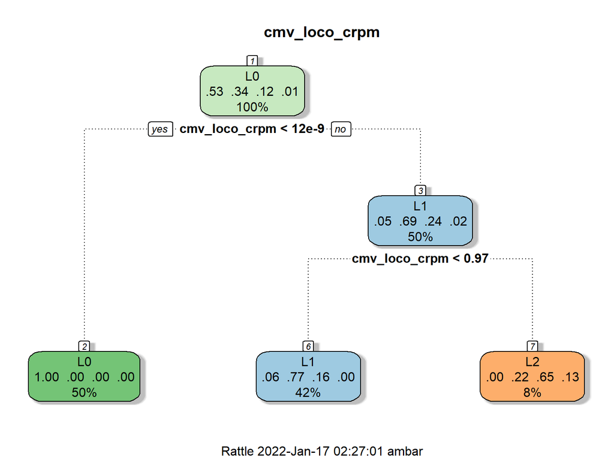

```r
tree2 <- rpart(level_of_threat ~ cmv_loco_crpm, data=train_cea, method="class")
fancyRpartPlot(tree2, main = "cmv_loco_crpm")
```

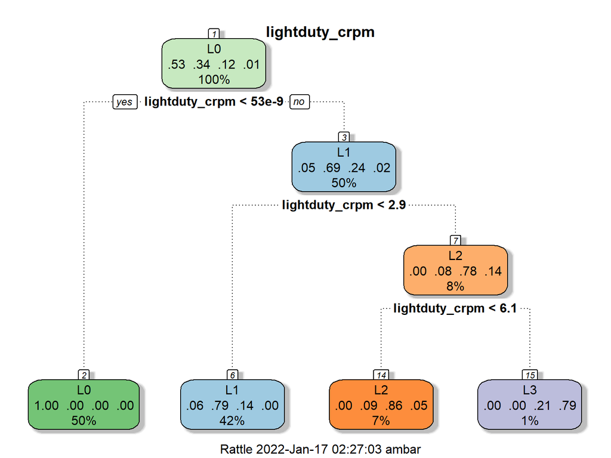

```r
tree3 <- rpart(level_of_threat ~ lightduty_crpm, data=train_cea, method="class")
fancyRpartPlot(tree3, main = "lightduty_crpm")
```

[figure not shown]

```r
tree4 <- rpart(level_of_threat ~ heavyduty_crpm, data=train_cea, method="class")
fancyRpartPlot(tree4, main = "heavyduty_crpm")
```

[figure not shown]

```
## [1] "Confusion Matrix is created"
## [1] "Accuracy : 94.84 %"
## [1] "Error : 5.16 %"
```

```
##    Precision (%) Recall (%) F1 Score (%)
## L0         99.64      95.62        97.59
## L1         90.02      97.17        93.46
## L2         90.24      87.04        88.61
## L3         79.48      68.82        73.77
```

```r
# 2. Train the model
rpart_tree <- rpart(level_of_threat ~ railyards_crpm+
                                      airport_crpm +
                                      rwc_crpm +
                                      cmv_crpm +
                                      biogenics_crpm +
                                      fires_crpm +
                                      secondary_crpm +
                                      np_10m_releaseheight_crpm +
                                      np_low_releaseheight_crpm +
                                      cmv_loco_crpm +
                                      lightduty_crpm +
                                      heavyduty_crpm,
                        data=train_cea, method="class")

# 3. Evaluate the trained model
model_predict(train_cea, rpart_tree, 'Training : Decision tree to identify the risk of Cancer')
```

[figure not shown]

```
## [1] "Confusion Matrix is created"
## [1] "Accuracy : 95 %"
## [1] "Error : 5 %"
```

```
##    Precision (%) Recall (%) F1 Score (%)
## L0         99.96      95.61        97.74
## L1         90.05      97.60        93.68
## L2         90.24      87.16        88.67
## L3         79.48      68.82        73.77
```

```r
# 4. Accuracy Tuning - (not needed if > 78~80%) - to identify more nodes
ctrl <- rpart.control(minsplit = 4,
    minbucket = round(5 / 3),
    maxdepth = 4,
    cp = 0)
tune_fit_train <- rpart(level_of_threat ~ railyards_crpm+
                                      airport_crpm +
                                      rwc_crpm +
                                      cmv_crpm +
                                      biogenics_crpm +
                                      fires_crpm +
                                      secondary_crpm +
                                      np_10m_releaseheight_crpm +
                                      np_low_releaseheight_crpm +
                                      cmv_loco_crpm +
                                      lightduty_crpm +
                                      heavyduty_crpm,
                        data=train_cea, method="class", control = ctrl)

model_predict(train_cea, tune_fit_train, 'Trained & Tuned : Decision tree to identify the risk of Cancer')
```

# Step 8 - Decision Trees Classifier - Test the model

1. Test the model using rpart()
2. Compare the results with Training dataset.

[figure not shown]

```
## [1] "Confusion Matrix is created"
## [1] "Accuracy : 95.09 %"
## [1] "Error : 4.91 %"
```

```
##    Precision (%) Recall (%) F1 Score (%)
## L0         99.95      95.63        97.74
## L1         89.80      97.87        93.66
## L2         92.26      85.35        88.67
## L3         78.24      86.55        82.18
```

```r
# 1. Test the model
tune_fit_test <- rpart(level_of_threat ~ railyards_crpm+
                                      airport_crpm +
                                      rwc_crpm +
                                      cmv_crpm +
                                      biogenics_crpm +
                                      fires_crpm +
                                      secondary_crpm +
                                      np_10m_releaseheight_crpm +
                                      np_low_releaseheight_crpm +
                                      cmv_loco_crpm +
                                      lightduty_crpm +
                                      heavyduty_crpm,
                        data=test_cea, method="class", control = ctrl)

# 2. Evaluate the tested model
model_predict(test_cea, tune_fit_test, 'Tested : Decision tree to identify the risk of Cancer')
```